# Joining Tables

Data is generally stored in multiple smaller tables. These smaller tables share a common variable or field, thus are related (which is why these tables are also known as relations). All the relations together comprise a relational database.

Storing data across relations offers a number of benefits such as reduced redundancy, fewer errors from updates, and greater efficiency in storage and retrieval. The data required for analysis at hand is retrieved by linking relations through joins. The languages most widely used for this is SQL, however, this note will illustrate the joins using R.

# Baseball Data

To illustrate joins, we will use baseball data compiled in library(Lahman) based on the [Lahman Database](http://www.seanlahman.com/)

```r
library(Lahman)
```

Baseball data is spread across a number of smaller tables.

```r
library(printr)
data(package = "Lahman")
```

Data sets in Lahman

| Item | Title |
| --- | --- |
| AllstarFull | AllstarFull table |
| Appearances | Appearances table |
| AwardsManagers | AwardsManagers table |
| AwardsPlayers | AwardsPlayers table |
| AwardsShareManagers | AwardsShareManagers table |
| AwardsSharePlayers | AwardsSharePlayers table |
| Batting | Batting table |
| BattingPost | BattingPost table |
| CollegePlaying | CollegePlaying table |
| Fielding | Fielding table |
| FieldingOF | FieldingOF table |
| FieldingOFsplit | FieldingOFsplit table |
| FieldingPost | FieldingPost data |
| HallOfFame | Hall of Fame Voting Data |
| HomeGames | HomeGames table |
| LahmanData | Lahman Datasets |
| Managers | Managers table |
| ManagersHalf | ManagersHalf table |
| Master | Master table |
| Parks | Parks table |
| People | People table |
| Pitching | Pitching table |
| PitchingPost | PitchingPost table |
| Salaries | Salaries table |
| Schools | Schools table |
| SeriesPost | SeriesPost table |
| Teams | Teams table |
| TeamsFranchises | TeamFranchises table |
| TeamsHalf | TeamsHalf table |
| battingLabels | Variable Labels |
| fieldingLabels | Variable Labels |
| pitchingLabels | Variable Labels |

# Teams data

In a well-designed relational database, each table has a variable, called a primary key, that uniquely identifies each row. Let us see if this is the case for the `Teams` table.

```r
detach('package:printr', unload = TRUE)
head(Teams)
```

```
##   yearID lgID teamID franchID divID Rank  G Ghome  W  L DivWin WCWin LgWin
## 1   1871   NA    BS1      BNA  <NA>    3 31    NA 20 10   <NA>  <NA>     N
## 2   1871   NA    CH1      CNA  <NA>    2 28    NA 19  9   <NA>  <NA>     N
## 3   1871   NA    CL1      CFC  <NA>    8 29    NA 10 19   <NA>  <NA>     N
## 4   1871   NA    FW1      KEK  <NA>    7 19    NA  7 12   <NA>  <NA>     N
## 5   1871   NA    NY2      NNA  <NA>    5 33    NA 16 17   <NA>  <NA>     N
## 6   1871   NA    PH1      PNA  <NA>    1 28    NA 21  7   <NA>  <NA>     Y
##   WSWin   R   AB   H X2B X3B HR BB SO SB CS HBP SF  RA  ER  ERA CG SHO SV
## 1  <NA> 401 1372 426  70  37  3 60 19 73 16  NA NA 303 109 3.55 22   1  3
## 2  <NA> 302 1196 323  52  21 10 60 22 69 21  NA NA 241  77 2.76 25   0  1
## 3  <NA> 249 1186 328  35  40  7 26 25 18  8  NA NA 341 116 4.11 23   0  0
## 4  <NA> 137  746 178  19   8  2 33  9 16  4  NA NA 243  97 5.17 19   1  0
## 5  <NA> 302 1404 403  43  21  1 33 15 46 15  NA NA 313 121 3.72 32   1  0
## 6  <NA> 376 1281 410  66  27  9 46 23 56 12  NA NA 266 137 4.95 27   0  0
##   IPouts  HA HRA BBA SOA   E DP    FP                    name
```

[output cut: 20 more lines]

Let us check to see if teamID uniquely identifies each row.

```r
library(dplyr)
Teams %>%
  group_by(teamID, name)%>%
  summarize(n = n())%>%
  filter(n>1)%>%
  arrange(desc(n))
```

| teamID | name | n |
| --- | --- | --- |
| PIT | Pittsburgh Pirates | 130 |
| PHI | Philadelphia Phillies | 129 |
| CIN | Cincinnati Reds | 125 |
| SLN | St. Louis Cardinals | 121 |
| CHA | Chicago White Sox | 120 |
| DET | Detroit Tigers | 120 |
| CHN | Chicago Cubs | 118 |
| BOS | Boston Red Sox | 113 |
| NYA | New York Yankees | 108 |
| CLE | Cleveland Indians | 106 |

[output cut: 106 more lines]

```r
head(Teams)
```

```
##   yearID lgID teamID franchID divID Rank  G Ghome  W  L DivWin WCWin LgWin
## 1   1871   NA    BS1      BNA  <NA>    3 31    NA 20 10   <NA>  <NA>     N
## 2   1871   NA    CH1      CNA  <NA>    2 28    NA 19  9   <NA>  <NA>     N
## 3   1871   NA    CL1      CFC  <NA>    8 29    NA 10 19   <NA>  <NA>     N
## 4   1871   NA    FW1      KEK  <NA>    7 19    NA  7 12   <NA>  <NA>     N
## 5   1871   NA    NY2      NNA  <NA>    5 33    NA 16 17   <NA>  <NA>     N
## 6   1871   NA    PH1      PNA  <NA>    1 28    NA 21  7   <NA>  <NA>     Y
##   WSWin   R   AB   H X2B X3B HR BB SO SB CS HBP SF  RA  ER  ERA CG SHO SV
## 1  <NA> 401 1372 426  70  37  3 60 19 73 16  NA NA 303 109 3.55 22   1  3
## 2  <NA> 302 1196 323  52  21 10 60 22 69 21  NA NA 241  77 2.76 25   0  1
## 3  <NA> 249 1186 328  35  40  7 26 25 18  8  NA NA 341 116 4.11 23   0  0
## 4  <NA> 137  746 178  19   8  2 33  9 16  4  NA NA 243  97 5.17 19   1  0
## 5  <NA> 302 1404 403  43  21  1 33 15 46 15  NA NA 313 121 3.72 32   1  0
## 6  <NA> 376 1281 410  66  27  9 46 23 56 12  NA NA 266 137 4.95 27   0  0
##   IPouts  HA HRA BBA SOA   E DP    FP                    name
```

[output cut: 20 more lines]

It is clear that `teamID` is repeated multiple times, so it does not uniquely identify each row. From reviewing the first few rows of `Teams`, you have probably realized that the table lists teams for each Year. So, let us see if each row is uniquely defined by `teamID` and `yearID`.

```r
Teams %>%
  group_by(teamID, yearID)%>%
  summarize(n = n())%>%
  filter(n>1)
```

| teamID | yearID | n |
| --- | --- | --- |

# Salaries data

From the above, it is clear that `teamID` and `yearID` uniquely identify each row in `Teams`. While this table is a rich source of information on team performance, it doesn’t contain any information on player Salary. Salary data is contained in a table called `Salaries`. However, salary data is at a more granular level, providing compensation for each player.

```r
head(Salaries)
```

```
##   yearID teamID lgID  playerID salary
## 1   1985    ATL   NL barkele01 870000
## 2   1985    ATL   NL bedrost01 550000
## 3   1985    ATL   NL benedbr01 545000
## 4   1985    ATL   NL  campri01 633333
## 5   1985    ATL   NL ceronri01 625000
## 6   1985    ATL   NL chambch01 800000
```

We will roll up the data to the team level by computing average player salary.

```r
team_salary =
  Salaries %>%
  group_by(yearID, teamID)%>%
  summarize(avgSalary = mean(salary,na.rm=T))
team_salary
```

| yearID | teamID | avgSalary |
| --- | --- | --- |
| 1985 | ATL | 673045.5 |
| 1985 | BAL | 525486.9 |
| 1985 | BOS | 435902.4 |
| 1985 | CAL | 515281.9 |
| 1985 | CHA | 468865.6 |
| 1985 | CHN | 577405.3 |
| 1985 | CIN | 379996.2 |
| 1985 | CLE | 327583.3 |
| 1985 | DET | 517407.2 |
| 1985 | HOU | 499652.5 |

[output cut: 908 more lines]

# Join Teams and Salaries

You will note that the `team_salary` data by `teamID` and `yearID` just like the `Teams` table. So, we can join the `Teams` data with `Salaries` using `teamID` and `yearID`. There are four kinds of joins: inner join, left outer, right outer and full outer join. An inner join will keep rows for which the keys match across the two tables. A left outer join will keep all rows in the table in the left and matching rows from the right. A right outer join will keep all rows in the table in the right and matching rows from the left. Finally, a full outer join will keep rows that match across the two tables and the ones that don’t match.

We want to only keep data for which there is a match across the `Teams` and `Salaries` table, so we implement an inner join using the `dplyr` function `inner_join`. An alternative is to use `merge()` from Base R.

```r
Teams %>%
  inner_join(team_salary, by = c('yearID' = 'yearID', 'teamID' = 'teamID'))%>%
  head()
```

```
##   yearID lgID teamID franchID divID Rank   G Ghome  W  L DivWin WCWin LgWin
## 1   1985   NL    ATL      ATL     W    5 162    81 66 96      N  <NA>     N
## 2   1985   AL    BAL      BAL     E    4 161    81 83 78      N  <NA>     N
## 3   1985   AL    BOS      BOS     E    5 163    81 81 81      N  <NA>     N
## 4   1985   AL    CAL      ANA     W    2 162    79 90 72      N  <NA>     N
## 5   1985   AL    CHA      CHW     W    3 163    81 85 77      N  <NA>     N
## 6   1985   NL    CHN      CHC     E    4 162    81 77 84      N  <NA>     N
##   WSWin   R   AB    H X2B X3B  HR  BB  SO  SB CS HBP SF  RA  ER  ERA CG SHO SV
## 1     N 632 5526 1359 213  28 126 553 849  72 52  22 41 781 679 4.19  9   9 29
## 2     N 818 5517 1451 234  22 214 604 908  69 43  19 40 764 694 4.38 32   6 33
## 3     N 800 5720 1615 292  31 162 562 816  66 27  30 57 720 659 4.06 35   8 29
## 4     N 732 5442 1364 215  31 153 648 902 106 51  39 35 703 633 3.91 22   8 41
## 5     N 736 5470 1386 247  37 146 471 843 108 56  43 45 720 656 4.07 20   8 39
## 6     N 686 5492 1397 239  28 150 562 937 182 49  18 39 729 666 4.16 20   8 42
##   IPouts   HA HRA BBA  SOA   E  DP    FP              name
```

[output cut: 20 more lines]

The joined table contains data on both team performance and average team salary. Now, one can filter the data to see if average salary paid is related to good performance or if it draws more fans. We measure performance as proportion of wins.

```r
Teams %>%
  inner_join(team_salary, by = c('yearID' = 'yearID', 'teamID' = 'teamID'))%>%
  mutate(win_ratio = W/(W+L))%>%
  select(yearID, teamID, name, win_ratio, avgSalary, attendance)%>%
  head()
```

```
##   yearID teamID              name win_ratio avgSalary attendance
## 1   1985    ATL    Atlanta Braves 0.4074074  673045.5    1350137
## 2   1985    BAL Baltimore Orioles 0.5155280  525486.9    2132387
## 3   1985    BOS    Boston Red Sox 0.5000000  435902.4    1786633
## 4   1985    CAL California Angels 0.5555556  515281.9    2567427
## 5   1985    CHA Chicago White Sox 0.5246914  468865.6    1669888
## 6   1985    CHN      Chicago Cubs 0.4782609  577405.3    2161534
```

Let us visualize the relationship between avgSalary and win_ratio for the the last 16 years. One of the consequences of an inner join is that it will only contain data for years that are present in both tables. Salary data is only available until 2016, so even though Teams data goes past 2016, it is not present in the joined table.

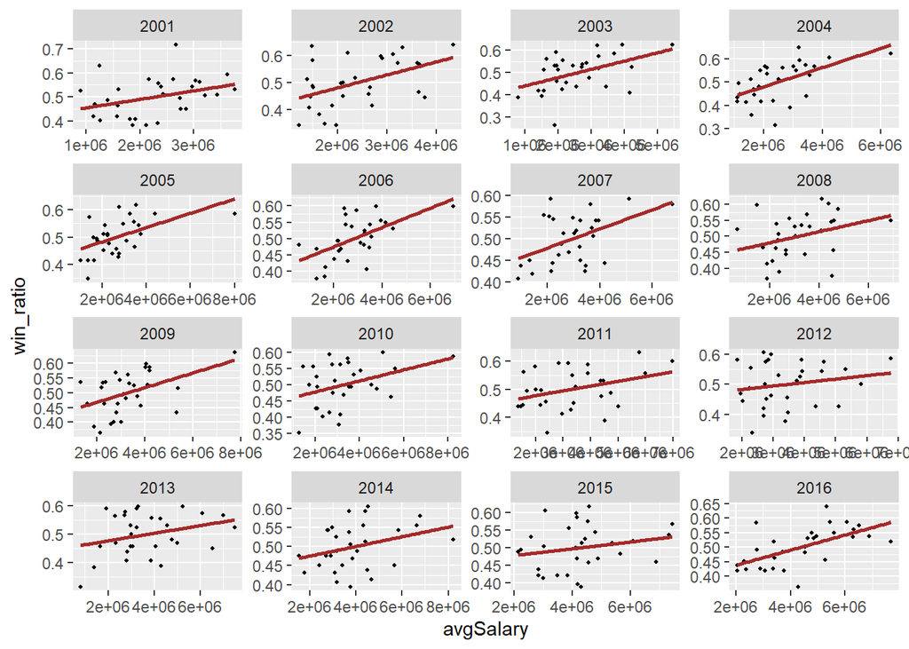

```r
library(ggplot2)
Teams %>%
  inner_join(team_salary, by = c('yearID' = 'yearID', 'teamID' = 'teamID'))%>%
  mutate(win_ratio = W/(W+L))%>%
  select(yearID, teamID, name, win_ratio, avgSalary, attendance)%>%
  filter(yearID%in%2001:2016)%>%
  ggplot(aes(x=avgSalary,y=win_ratio))+
  geom_point(size=0.8)+
  geom_smooth(method='lm', se=F,color='brown')+
  facet_wrap(~yearID,scales = 'free')
```

By joining two different tables, we were able to examine the relationship between avgSalary paid to each player and the team win-ratio. What do you think? (Caveat: If you suspect relationship of salary on performance is delayed, then you can examine the relationship between win_ratio and a lagged avgSalary)